# Data Science I, Workshop I: Predicting interest rates at the Lending Club

# 7 Sample size estimation and learning curves

- We can use the hold out method for out-of-sample testing to check if we have a sufficiently large sample to estimate the model reliably.
- The idea is to set aside some of the data as a testing set. From the remaining data draw progressively larger training sets and check how the performance of the model on the testing set changes. If the performance no longer improves with larger training sets we know we have a large enough sample. The code below does this. Examine it and run it with different random seeds.

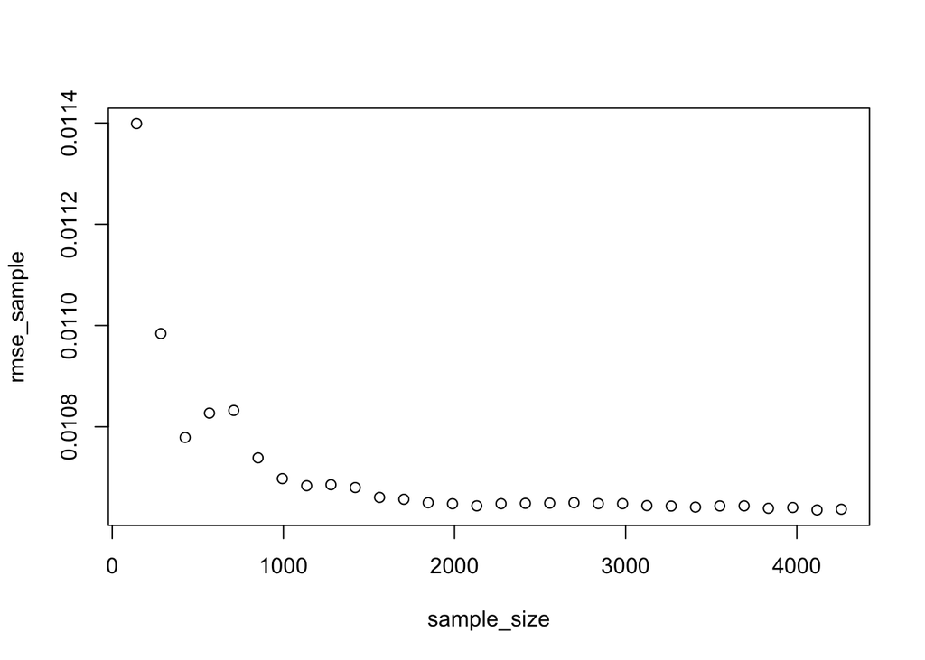

```r
#select a testing dataset (25% of all data)
set.seed(12)

train_test_split <- initial_split(lc_clean, prop = 0.75)
remaining <- training(train_test_split)
testing <- testing(train_test_split)

#We are now going to run 30 models starting from a tiny training set drawn from the training data and progressively increasing its size. The testing set remains the same in all iterations.

#initiating the model by setting some parameters to zero
rmse_sample <- 0
sample_size<-0
Rsq_sample<-0

for(i in 1:30) {
#from the remaining dataset select a smaller subset to training the data
set.seed(100)
sample

  learning_split <- initial_split(remaining, prop = i/200)
  training <- training(learning_split)
  sample_size[i]=nrow(training)

  #traing the model on the small dataset
  model3<-lm(int_rate ~ loan_amnt + term+ dti + annual_inc + grade + grade:loan_amnt, training)
  #test the performance of the model on the large testing dataset. This stays fixed for all iterations.
  pred<-predict(model3,testing)
  rmse_sample[i]<-RMSE(pred,testing$int_rate)
  Rsq_sample[i]<-R2(pred,testing$int_rate)
}
plot(sample_size,rmse_sample)
```

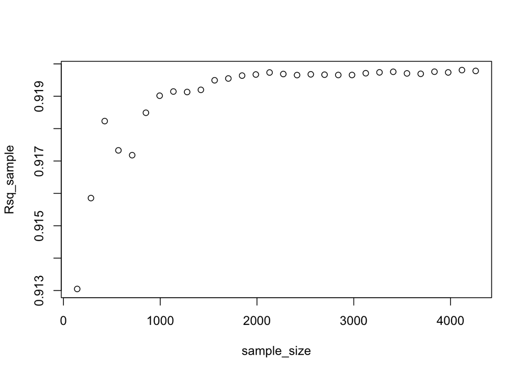

```r
plot(sample_size,Rsq_sample)
```

## 7.1 Q6 Analysis on learning curves

- When looking at the RMSE and R squared graphs, we can see that the RMSE decreases and the R squared increases a lot more before reaching the sample size of 2,000.
- This means that we would need approximately 2,000 in our sample size in order to estimate model 3 reliably. Once we reach this sample size, we can reduce the prediction error by changing the variables in our model (feature engineering), but not increasing sample size.